# P4：拍拍贷业务数据探索

## 性别和（金额）坏账率的关系：

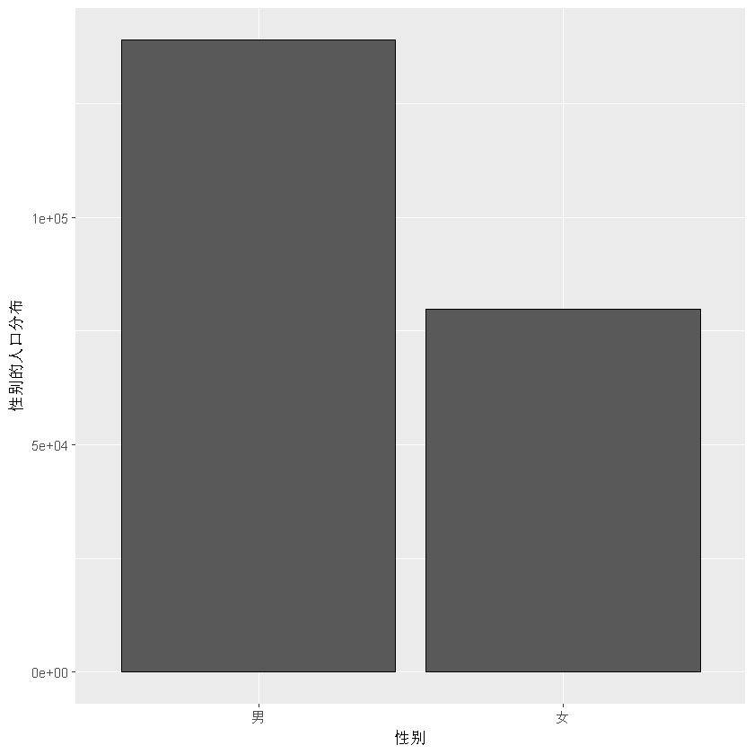

```r
ggplot(data=ppd,aes(性别))+
geom_bar(color='black')+
ylab('性别的人口分布')
```

```r
hz<-subset(ppd,标当前逾期天数==1)
```

```r
hz<-hz%>%
group_by(性别)%>%
summarise(坏账金额=sum(总待还本金))
```

```r
zj<-ppd%>%
group_by(性别)%>%
summarise(总借款金额=sum(历史成功借款金额),
            性别人口分布=n())
```

```r
zj$坏账金额<-hz$坏账金额
```

```r
zj$金额坏账率<-(zj$坏账金额)/(zj$总借款金额)
```

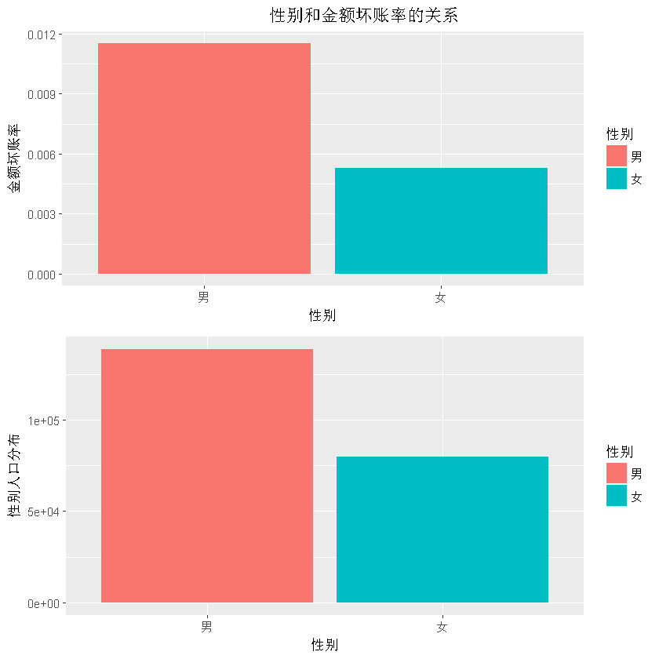

```r
p1<-ggplot(data=zj,aes(x=性别,y=金额坏账率))+
geom_bar(stat='identity',aes(fill=性别))+
ggtitle('                                            性别和金额坏账率的关系')
p2<-ggplot(data=zj,aes(x=性别,y=性别人口分布))+
geom_bar(stat='identity',aes(fill=性别))
grid.arrange(p1,p2,ncol=1)
```

#### 小结：

#### 从柱状图可以看出男性的金额坏账率要高于女性

## 性别、初始评级和金额坏账率的关系：

#### 去除掉异常值AAA和EF，探索总体的趋势。

```r
hz<-subset(ppd,标当前逾期天数==1)
```

```r
xb_pj_hz<-hz%>%
group_by(性别,初始评级)%>%
summarise(坏账金额=sum(总待还本金),
         坏账金额人口分布=n())
```

```r
xb_pj_zj<-ppd%>%
group_by(性别,初始评级)%>%
summarise(总借款金额=sum(历史成功借款金额),
         总借款金额人口分布=n())
```

```r
xb_pj_zj_sub<-xb_pj_zj[c(-9,-10,-16),]
```

```r
xb_pj_zj_sub$金额坏账率<-(xb_pj_hz$坏账金额)/(xb_pj_zj_sub$总借款金额)
```

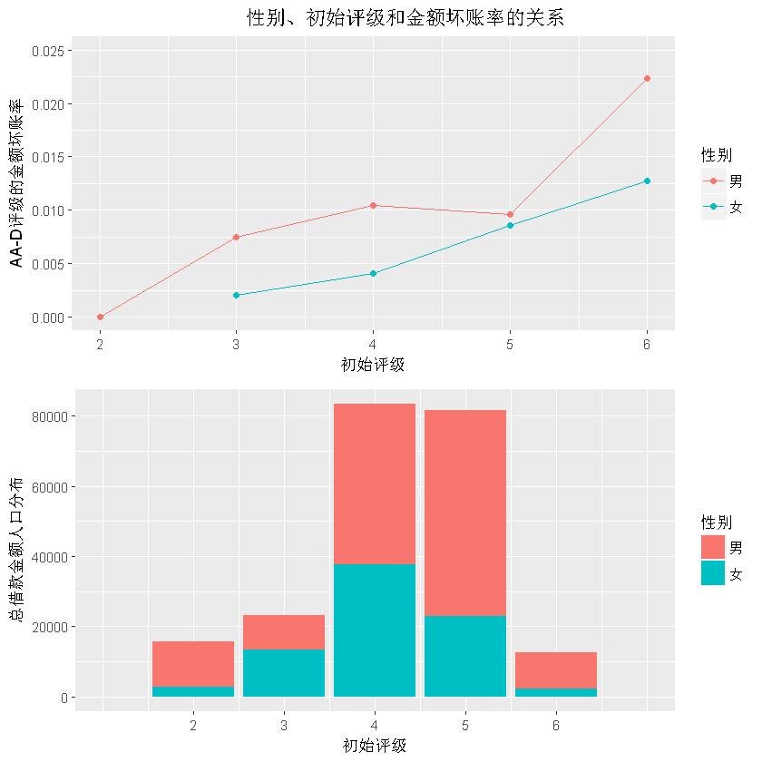

```r
#p1<-ggplot(data=xb_pj_zj_sub,aes(x=初始评级,y=金额坏账率))+
#geom_bar(stat='identity',aes(fill=性别))+
#ylab('AAA-F评级的金额坏账率')+
#ggtitle('                                性别、初始评级和金额坏账率的关系')

p3<-ggplot(data=xb_pj_zj,aes(x=初始评级,y=总借款金额人口分布))+
geom_bar(stat='identity',aes(fill=性别))+
scale_x_continuous(limits=c(1,7),breaks=seq(2,6,1))

p2<-ggplot(data=xb_pj_zj_sub,aes(x=初始评级,y=金额坏账率))+
geom_line(aes(color=性别))+
geom_point(aes(color=性别))+
scale_x_continuous(limits=c(2,6),breaks=seq(2,6,1))+
coord_cartesian(ylim=c(0,0.025))+
ylab('AA-D评级的金额坏账率')+
ggtitle('                                性别、初始评级和金额坏账率的关系')

grid.arrange(p2,p3,ncol=1)
```

### 小结：

#### 从AA-D的金额坏账率折线图可以看出，在不同的初始评级中，男性的金额坏账率普遍高于女性。

#### 随着评级的下降，男性和女性的坏账率都在上升。D评级的女性坏账率为1.2%，D评级的男性坏账率为2.2%，是评级中最高的坏账率。

#### 如果在拍拍贷投资，最好选择女性，且评级越靠前坏账率越低，投资风险也就越低。

#### 专门对异常值AAA评级与金额坏账率关系的深入研究：

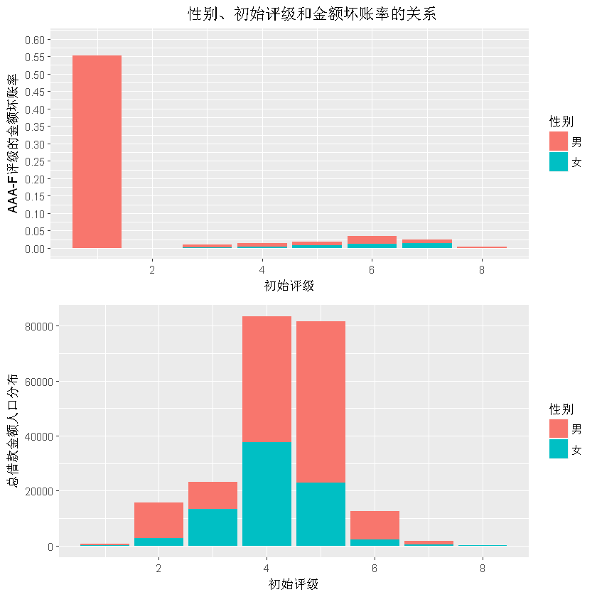

```r
p1<-ggplot(data=xb_pj_zj_sub,aes(x=初始评级,y=金额坏账率))+
geom_bar(stat='identity',aes(fill=性别))+
ylab('AAA-F评级的金额坏账率')+
scale_y_continuous(limits=c(0,0.6),breaks=seq(0,0.6,0.05))+
ggtitle('                                性别、初始评级和金额坏账率的关系')

p2<-ggplot(data=xb_pj_zj,aes(x=初始评级,y=总借款金额人口分布))+
geom_bar(stat='identity',aes(fill=性别))


grid.arrange(p1,p2,ncol=1)
```

#### 小结：

#### AAA评级的男性(金额)坏账率高达55%,这是很反常的事情，按理说评级越高，坏账率应该越低，可是只有AAA评级的男性反常。

#### 推测：拍拍贷平台给与这些AAA评级的标准应该是没有问题的，问题因该出在，这些男性借款人身上。

#### 很有可能是，有些人恶意伪造了身份以及财产证明等高信用等级指标，导致网站给与了这些男性最高的初始评级。

#### 而这些人，也正是利用了投资人对网站给出的高初始评级的信任，从平台借出巨额资金，然后卷款潜逃。

#### 所以对于投资者来说，对于AAA初始评级的男性借款人一定要谨慎，尽量不投，否则可能血本无归。很有可能高级老赖就隐藏在这里。

#### 另外，AAA评级的女性和AA评级的女性，金额坏账率为0，她们都是极为安全的投资对象，投资者可以重点考虑。

#### 对比推测：

#### AAA评级的男性(人口)坏账率为1.5%

#### AAA评级的男性(金额)坏账率高达55%

#### 通过这个对比，可以得知，并不是AAA评级的大部分男性都是恶意借款人，恶意借款人的比例只有1.5%

#### 造成AAA评级金额坏账率高达55%的原因是，极少部分的高级骗贷人员，骗取了AAA评级中大部分的投资金额，他们是AAA高坏账率的来源

# 结论：

#### 1.拍拍贷平台的逾期还款率不受年龄和初始评级的影响，逾期还款率基本稳定在2.5%-5%之间。

#### 2.初始评级和人口坏账率呈现极强的负相关性，如果投资，最好选择初始评级高的借款人，这样坏账率会比较低，可以降低投资风险。

#### 3.AAA评级的男性金额坏账率高达55%，很多高级老赖就隐藏在这里，投资人一定要倍加小心，尽量避免投资该评级的男性借款人。

#### 4.AAA评级的女性和AA评级的女性，金额坏账率为0，她们都是极为安全的投资对象，投资者可以重点考虑。

#### 5.男性的人口坏账率和金额坏账率均明显高于女性，因此投资时，最好选择女性借款人，可以大大降低投资风险。

#### 6.投资最好选择26岁以下的借款人，他们的坏账率低于0.5%，投资风险较低，千万不要选择35岁的借款人，他们的坏账率为5%是最高的。

#### 7.借款期限24个月的借款人，坏账率高达3.5%，选择24个月借款期限的很有可能是老赖或者无偿还能力的借款者，尽量避免这类投资。

#### 8.手机认证成功的借款人金额坏账率为1.5%是未手机认证的借款人坏账率的5倍，这个特点是非常值得投资人注意的。

#### 9.利率在13以下的标的坏账率为0，是最安全的标的。利率为16,20,22的标的投资人数最多且金额坏账率不超过1%，风险不高回报率很高。

#### 10.大部分成功注册用户的金额坏账率远远高于未成功注册用户的金额坏账率，因此投标时可以尽可能选择那些未成功注册的用户。

#### 11.本次探索性数据分析，仅对拍拍贷部分数据进行分析，并不全面，后续还需要进行更深入的探索和分析。